# Master Business Intelligence

# Reglas de Asociación

Autor: Albert Campano

Enero 2020

# 1 Introducción

## 1.1 Descripción de la PEC a realizar

La prueba está estructurada en un total de 5 ejercicios prácticos. Es necesario hacerlos todos para obtener una valoración máxima.

## 1.2 Criterios de valoración

| Pregunta | Criterio de valoración | Peso |
| --- | --- | --- |
| 1 | Se explican los distintos métodos que acepta la función | 10% |
| 1 | Se aplican los métodos y se muestran los resultados | 10% |
| 2 | Se listan las 10 reglas solicitadas | 5% |
| 2 | Se genera y se comenta el gráfico solicitado | 5% |
| 2 | Se comentan 2 reglas de las 10 generadas | 10% |
| 3 | Se explica para que sirve la función coverage() | 5% |
| 3 | Se listan las 10 reglas solicitadas | 5% |
| 3 | Se genera y se comenta el gráfico solicitado | 10% |
| 4 | Se generan y se muestran los sets solicitados | 5% |
| 4 | Se listan las 10 reglas solicitadas | 10% |
| 5 | Se explica el significado de los 3 conceptos solicitados | 5% |
| 5 | Se explica una regla detallando el significado en la regla del soporte, confianza y elevación | 10% |
| 6 | Se plasma a través de una redacción extensa el conocimiento obtenido a partir de las reglas generadas | 10% |

## 1.3 Formato y fecha de entega

El formato de entrega es: studentname-PECn.html  
Fecha de Entrega: 02/02/2020  
Se debe entregar la PEC en el buzón de entregas del aula

# 2 Información técnica de la PEC

A continuación se ofrece información técnica sobre el entorno en el que se ha generado este documento

```r
# Encoding utilizado: UTF-8

# Datos de sistema operativo y versión R
version
```

```
##                _
## platform       x86_64-w64-mingw32
## arch           x86_64
## os             mingw32
## system         x86_64, mingw32
## status
## major          3
## minor          4.4
## year           2018
## month          03
## day            15
## svn rev        74408
## language       R
## version.string R version 3.4.4 (2018-03-15)
## nickname       Someone to Lean On
```

```r
# Versión de los paquetes utilizados:
# Paquete arules
packageVersion("arules")
```

```
## [1] '1.6.3'
```

```r
# Paquete arulesViz
packageVersion("arulesViz")
```

```
## [1] '1.3.3'
```

# 3 Base teórica

Para realizar la práctica se recomienda la lectura del punto 3.4 del material didáctico. Este punto se centra en la búsqueda de asociaciones las cuales en nuestro caso se darán entre las características de la población adulta de USA.

El algoritmo **apriori** fue diseñado para la búsqueda de asociaciones entre los productos que forman parte de la cesta de la compra en el supermercado, hipermercado o gran superficie. El objetivo era determinar qué productos eran causa de la compra de otros. Sin embargo, el algoritmo **apriori** puede generalizarse para la búsqueda de asociaciones entre cualquier conjunto de items.

En esta PEC el objetivo será buscar asociaciones y relaciones en un juego de datos sobre la población adulta de USA. Se han identificado una serie de características de la misma y se quiere averiguar si existen relaciones entre ellas.

Para ello utilizaremos el paquete **R** denominado **arules** del que podréis encontrar información extensa en el siguiente enlace https://cran.r-project.org/web/packages/arules/vignettes/arules.pdf

# 4 Descripción del problema

Vamos a analizar la relación entre características que definen la población adulta de USA según las siguientes variables.

1. age
2. workclass
3. fnlwgt: final weight
4. education
5. education-num
6. marital-status
7. occuptaion
8. relationship
9. race
10. sex
11. capital-gain
12. capital-loss
13. hours-per-week
14. native-country
15. income

Podéis encontrar más información sobre el juego de datos en el siguiente enlace https://archive.ics.uci.edu/ml/datasets/adult

# 5 Cargar el juego de datos

El juego de datos forma parte de los ejemplos del paquete **arules**, por lo que una vez cargado el paquete simplemente tendremos que llamarlo. Para poder ser usado por algoritmos de búsqueda de asociaciones el juego de datos debe tener una estructura de transacciones en la que cada fila represente una transacción, por ejemplo en una cesta de la compra diríamos que cada fila representa una compra.

En nuestro caso una transacción o fila del juego de datos representa un individuo de la población de USA.

La generación de reglas de asociación requiere que las características a estudiar sean categóricas y no continuas, por este motivo debemos prever un proceso de conversión de variables continuas en categóricas, para ello nos apoyaremos en la función de **R** **cut()**.

```r
library(arules)
```

```r
library(arulesViz)
data("AdultUCI")

# Proceso de categorización de variables continuas
AdultC <- AdultUCI
AdultC$age <- cut(AdultUCI$age, c(15,25,30,35,45,55,65,100))
AdultC$workclass <- AdultUCI$workclass
AdultC$fnlwgt <- cut(AdultUCI$fnlwgt, c(12200,20000,50000,100000,500000,750000,1000000,1500000))
AdultC$education <- AdultUCI$education
AdultC$`education-num` <- cut(AdultUCI$`education-num`, c(1,5,10,15,20))
AdultC$`marital-status` <- AdultUCI$`marital-status`
AdultC$occupation <- AdultUCI$occupation
AdultC$relationship <- AdultUCI$relationship
AdultC$race <- AdultUCI$race
AdultC$sex <- AdultUCI$sex
AdultC$`capital-gain` <- cut(AdultUCI$`capital-gain`, c(0,15000,20000,30000,40000,50000,60000,80000,100000))
AdultC$`capital-loss` <- cut(AdultUCI$`capital-loss`, c(0,500,1000,2000,3000,4000,5000))
AdultC$`hours-per-week` <- cut(AdultUCI$`hours-per-week`, c(0,10,20,30,50,60,80,100))
AdultC$`native-country` <- AdultUCI$`native-country`
AdultC$income <- AdultUCI$income
```

# 6 Función arules()

En R el juego de datos debe estar en formato **transaction**. Si no lo está, deberemos usar comandos de **R** para proceder a su conversión.  
Observamos que en el proceso de generación de reglas exigimos un soporte y una confianza mínimos.

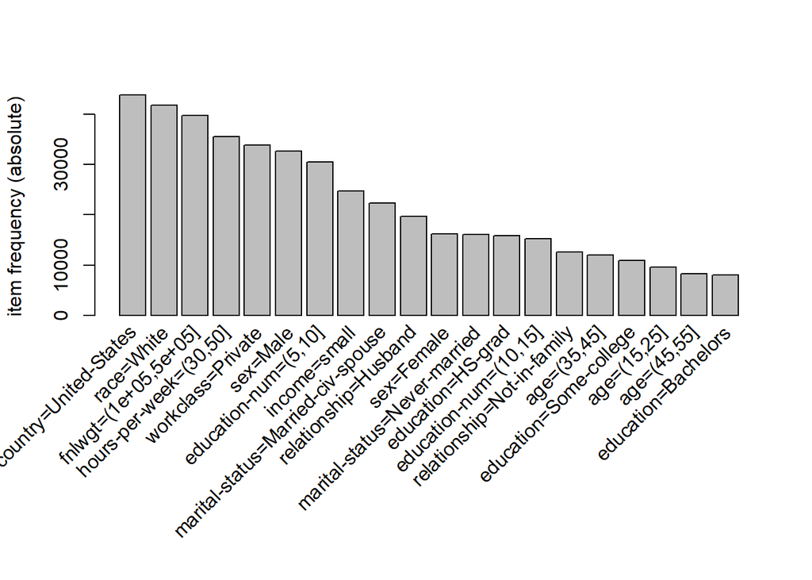

```r
# Conversión del juego de datos a formato transacción
Adult = as(AdultC, "transactions")

# Visualizamos un histograma de frecuencias
itemFrequencyPlot(Adult,topN=20,type="absolute")
```

```r
# Generación de reglas con soporte y confianza mínimos
rules = apriori(Adult, parameter=list(support=0.01, confidence=0.7, maxlen=7))
```

```
## Apriori
##
## Parameter specification:
##  confidence minval smax arem  aval originalSupport maxtime support minlen
##         0.7    0.1    1 none FALSE            TRUE       5    0.01      1
##  maxlen target   ext
##       7  rules FALSE
##
## Algorithmic control:
##  filter tree heap memopt load sort verbose
##     0.1 TRUE TRUE  FALSE TRUE    2    TRUE
##
## Absolute minimum support count: 488
##
## set item appearances ...[0 item(s)] done [0.00s].
## set transactions ...[138 item(s), 48842 transaction(s)] done [0.01s].
## sorting and recoding items ... [76 item(s)] done [0.02s].
## creating transaction tree ... done [0.02s].
## checking subsets of size 1 2 3 4 5 6 7
```

```
##  done [0.66s].
## writing ... [170708 rule(s)] done [0.05s].
## creating S4 object  ... done [0.22s].
```

```r
# Listado de reglas obtenidas
rules
```

```
## set of 170708 rules
```

Vemos como el número de reglas que se han formado superan las 170000, por ello es importante poder filtrar entre las reglas generadas, siendo tarea del analista identificar las más representativas. Mostramos a continuación formas distintas de filtrado de reglas.

```r
# Listamos las 3 reglas con mayor lift
inspect(head(sort(rules, by="lift"),3));
```

```
##     lhs                        rhs                        support confidence     lift count
## [1] {education=Doctorate}   => {education-num=(15,20]} 0.01216166          1 82.22559   594
## [2] {education-num=(15,20]} => {education=Doctorate}   0.01216166          1 82.22559   594
## [3] {education=Doctorate,
##      race=White}            => {education-num=(15,20]} 0.01076942          1 82.22559   526
```

```r
# Visualizamos la calidad de las reglas generadas
head(quality(rules));
```

```
##      support confidence      lift count
## 1 0.72798002  0.7279800  1.000000 35556
## 2 0.81364399  0.8136440  1.000000 39740
## 3 0.85504279  0.8550428  1.000000 41762
## 4 0.89742435  0.8974243  1.000000 43832
## 5 0.01042136  1.0000000 19.798135   509
## 6 0.01050326  0.9624765  2.100598   513
```

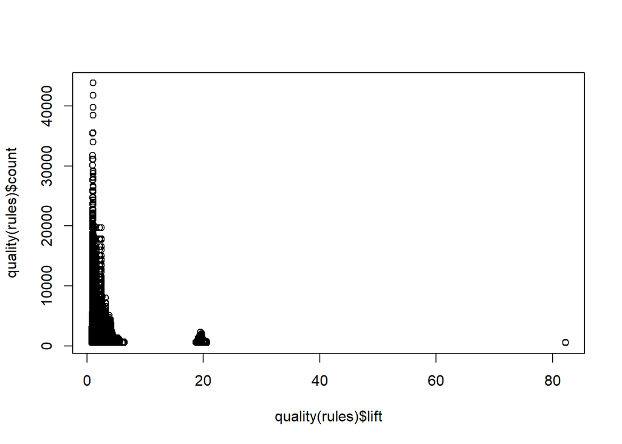

```r
# Generamos gráfico de frecuencias por elevación
plot(quality(rules)$lift,quality(rules)$count)
```

Más técnicas de filtrado de reglas

```r
# Extracción de reglas con una confianza superior a 0.8
subrules = rules[quality(rules)$confidence > 0.8]

subrules
```

```
## set of 131801 rules
```

Filtramos las 20 reglas con mayor elevación y posteriormente las listamos

```r
subrules2 = head(sort(rules, by="lift"), 20);

subrules2
```

```
## set of 20 rules
```

```r
inspect(subrules2)
```

```
##      lhs                                    rhs                        support confidence     lift count
## [1]  {education=Doctorate}               => {education-num=(15,20]} 0.01216166  1.0000000 82.22559   594
## [2]  {education-num=(15,20]}             => {education=Doctorate}   0.01216166  1.0000000 82.22559   594
## [3]  {education=Doctorate,
##       race=White}                        => {education-num=(15,20]} 0.01076942  1.0000000 82.22559   526
## [4]  {education-num=(15,20],
##       race=White}                        => {education=Doctorate}   0.01076942  1.0000000 82.22559   526
## [5]  {fnlwgt=(1e+05,5e+05],
##       marital-status=Married-civ-spouse,
##       race=White,
##       sex=Female,
##       native-country=United-States,
##       income=large}                      => {relationship=Wife}     0.01009377  0.9840319 20.61866   493
## [6]  {marital-status=Married-civ-spouse,
##       race=White,
##       sex=Female,
##       native-country=United-States,
##       income=large}                      => {relationship=Wife}     0.01238688  0.9837398 20.61254   605
## [7]  {marital-status=Married-civ-spouse,
##       sex=Female,
##       native-country=United-States,
##       income=large}                      => {relationship=Wife}     0.01359486  0.9822485 20.58129   664
## [8]  {marital-status=Married-civ-spouse,
##       race=White,
##       sex=Female,
##       income=large}                      => {relationship=Wife}     0.01328774  0.9818457 20.57285   649
## [9]  {fnlwgt=(1e+05,5e+05],
##       marital-status=Married-civ-spouse,
##       sex=Female,
##       native-country=United-States,
##       income=large}                      => {relationship=Wife}     0.01101511  0.9817518 20.57088   538
## [10] {fnlwgt=(1e+05,5e+05],
##       marital-status=Married-civ-spouse,
##       race=White,
##       sex=Female,
##       income=large}                      => {relationship=Wife}     0.01081037  0.9814126 20.56377   528
## [11] {marital-status=Married-civ-spouse,
##       sex=Female,
##       hours-per-week=(30,50],
##       native-country=United-States,
```

[output cut: 27 more lines]

```
##       native-country=United-States}      => {relationship=Wife}     0.01267352  0.9748031 20.42528   619
## [18] {education-num=(10,15],
##       marital-status=Married-civ-spouse,
##       race=White,
##       sex=Female,
##       native-country=United-States}      => {relationship=Wife}     0.01443430  0.9737569 20.40336   705
## [19] {education-num=(10,15],
##       marital-status=Married-civ-spouse,
##       sex=Female,
##       hours-per-week=(30,50],
##       native-country=United-States}      => {relationship=Wife}     0.01126080  0.9734513 20.39696   550
## [20] {education-num=(10,15],
##       marital-status=Married-civ-spouse,
##       sex=Female,
##       native-country=United-States}      => {relationship=Wife}     0.01611318  0.9716049 20.35827   787
```

```r
oneRule = sample(rules, 1);

inspect(oneRule);
```

```
##     lhs                      rhs                         support confidence     lift count
## [1] {workclass=State-gov,
##      race=White,
##      income=small}        => {hours-per-week=(30,50]} 0.01142459  0.7380952 1.013895   558
```

# 7 Visualizaciones de reglas

La forma más habitual de trabajar con reglas es listarlas en forma de tabla, que es lo que hemos hecho hasta ahora.

```r
inspectRules <- inspect(rules[1:10], ruleSep = "---->", itemSep = " + ", setStart = "", setEnd ="", linebreak = FALSE)
```

```
##      lhs                                rhs
## [1]                               ----> hours-per-week=(30,50]
## [2]                               ----> fnlwgt=(1e+05,5e+05]
## [3]                               ----> race=White
## [4]                               ----> native-country=United-States
## [5]  education=5th-6th            ----> education-num=(1,5]
## [6]  capital-gain=(1.5e+04,2e+04] ----> marital-status=Married-civ-spouse
## [7]  capital-gain=(1.5e+04,2e+04] ----> race=White
## [8]  education=Doctorate          ----> education-num=(15,20]
## [9]  education-num=(15,20]        ----> education=Doctorate
## [10] education=Doctorate          ----> race=White
##      support    confidence lift      count
## [1]  0.72798002 0.7279800   1.000000 35556
## [2]  0.81364399 0.8136440   1.000000 39740
## [3]  0.85504279 0.8550428   1.000000 41762
## [4]  0.89742435 0.8974243   1.000000 43832
## [5]  0.01042136 1.0000000  19.798135   509
## [6]  0.01050326 0.9624765   2.100598   513
## [7]  0.01003235 0.9193246   1.075180   490
## [8]  0.01216166 1.0000000  82.225589   594
## [9]  0.01216166 1.0000000  82.225589   594
## [10] 0.01076942 0.8855219   1.035646   526
```

```r
knitr::kable(inspectRules)
```

|  | lhs |  | rhs | support | confidence | lift | count |
| --- | --- | --- | --- | --- | --- | --- | --- |
| [1] |  | —-> | hours-per-week=(30,50] | 0.7279800 | 0.7279800 | 1.000000 | 35556 |
| [2] |  | —-> | fnlwgt=(1e+05,5e+05] | 0.8136440 | 0.8136440 | 1.000000 | 39740 |
| [3] |  | —-> | race=White | 0.8550428 | 0.8550428 | 1.000000 | 41762 |
| [4] |  | —-> | native-country=United-States | 0.8974243 | 0.8974243 | 1.000000 | 43832 |
| [5] | education=5th-6th | —-> | education-num=(1,5] | 0.0104214 | 1.0000000 | 19.798135 | 509 |
| [6] | capital-gain=(1.5e+04,2e+04] | —-> | marital-status=Married-civ-spouse | 0.0105033 | 0.9624765 | 2.100598 | 513 |
| [7] | capital-gain=(1.5e+04,2e+04] | —-> | race=White | 0.0100323 | 0.9193246 | 1.075180 | 490 |
| [8] | education=Doctorate | —-> | education-num=(15,20] | 0.0121617 | 1.0000000 | 82.225589 | 594 |
| [9] | education-num=(15,20] | —-> | education=Doctorate | 0.0121617 | 1.0000000 | 82.225589 | 594 |
| [10] | education=Doctorate | —-> | race=White | 0.0107694 | 0.8855219 | 1.035646 | 526 |

Sin embargo, existen técnicas más gráficas como los árboles de reglas.

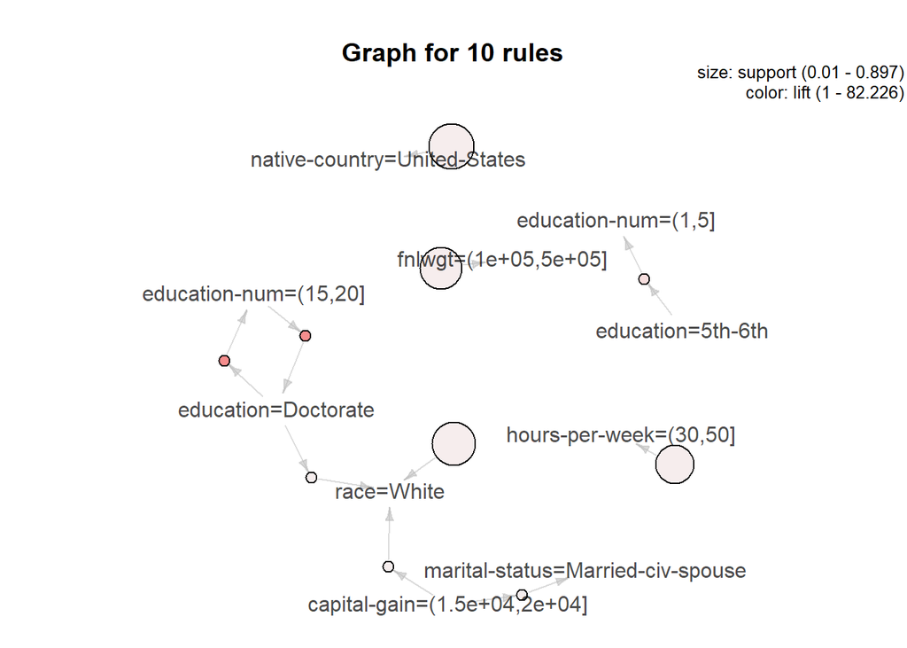

```r
library(arulesViz)
# Gráfico basado en árboles de reglas
plot(rules[1:10], method="graph")
```

```
## To reduce overplotting, jitter is added! Use jitter = 0 to prevent jitter.
```

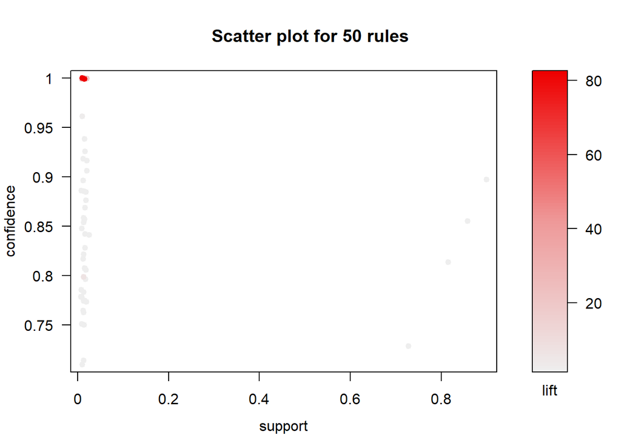

```r
# Gráfico de puntos
plot(rules[1:50], measure=c("support", "confidence"), shading="lift")
```

```
## To reduce overplotting, jitter is added! Use jitter = 0 to prevent jitter.
```

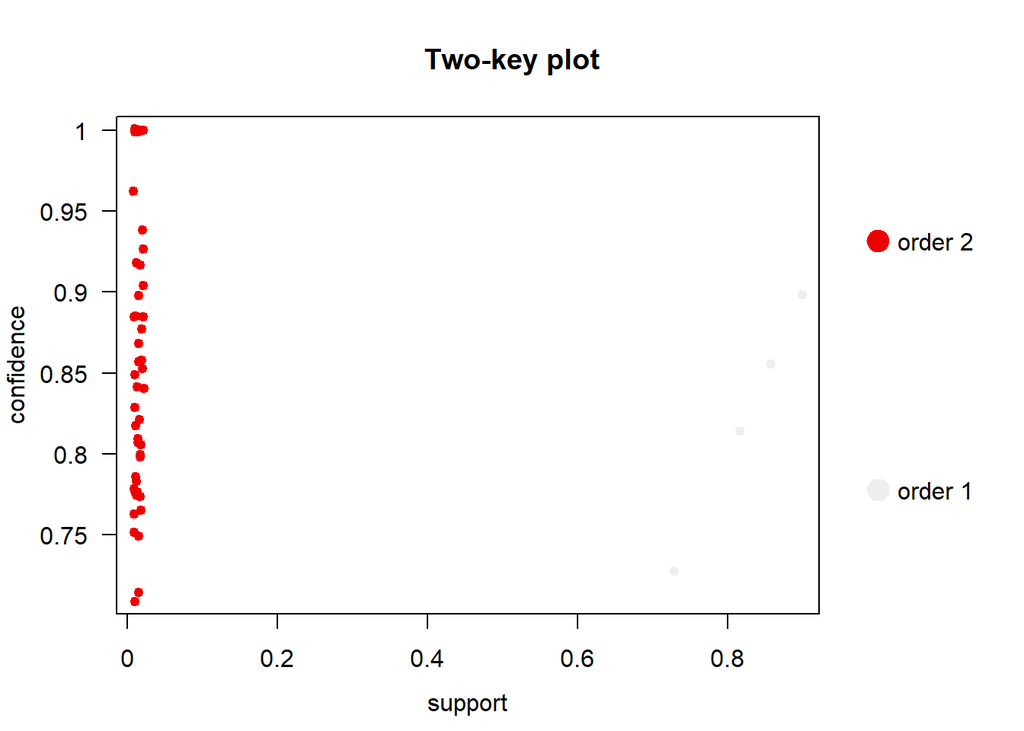

```r
plot(rules[1:50], shading="order", control=list(main = "Two-key plot"))
```

```
## Itemsets in Antecedent (LHS)
##  [1] "{education=Doctorate}"
##  [2] "{education-num=(15,20]}"
##  [3] "{education=5th-6th}"
##  [4] "{education=7th-8th}"
##  [5] "{education=9th}"
##  [6] "{education=Prof-school}"
##  [7] "{capital-gain=(1.5e+04,2e+04]}"
##  [8] "{hours-per-week=(60,80]}"
##  [9] "{native-country=Mexico}"
## [10] "{education=12th}"
## [11] "{occupation=Protective-serv}"
## [12] "{marital-status=Married-spouse-absent}"
## [13] "{}"
## [14] "{hours-per-week=(0,10]}"
## Itemsets in Consequent (RHS)
##  [1] "{native-country=United-States}"
##  [2] "{race=White}"
##  [3] "{fnlwgt=(1e+05,5e+05]}"
##  [4] "{hours-per-week=(30,50]}"
##  [5] "{workclass=Private}"
##  [6] "{sex=Male}"
##  [7] "{education-num=(5,10]}"
##  [8] "{marital-status=Married-civ-spouse}"
##  [9] "{education-num=(10,15]}"
## [10] "{occupation=Prof-specialty}"
## [11] "{education-num=(1,5]}"
## [12] "{education-num=(15,20]}"
## [13] "{education=Doctorate}"
```

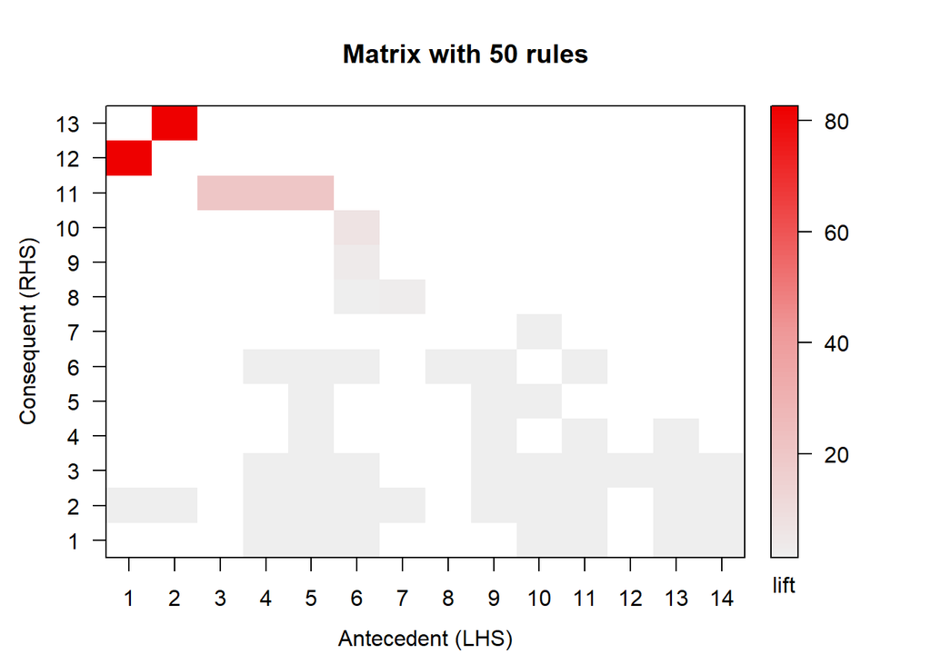

```r
# Comparando rhs con lhs
plot(rules[1:50], method="matrix", measure="lift")
```

# 8 Función eclat()

Una aproximación distinta puede ser usar la función **R** **eclat()** para identificar los valores más significativos de las distintas características

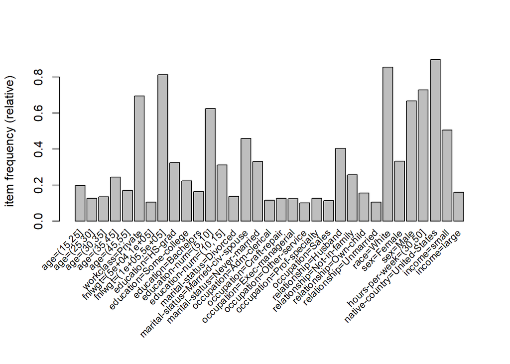

```r
itemFrequencyPlot(Adult, support = 0.1, cex.names=0.8)
```

```r
# Creamos sets o combinaciones de características según su relevancia.
fsets = eclat(Adult, parameter = list(support = 0.05), control = list(verbose=FALSE));
summary(fsets)
```

```
## set of 6270 itemsets
##
## most frequent items:
## native-country=United-States                   race=White
##                         2921                         2803
##         fnlwgt=(1e+05,5e+05]       hours-per-week=(30,50]
##                         2613                         2337
##            workclass=Private                      (Other)
##                         2304                        15412
##
## element (itemset/transaction) length distribution:sizes
##    1    2    3    4    5    6    7    8    9   10
##   45  331 1037 1733 1679  983  363   86   12    1
##
##    Min. 1st Qu.  Median    Mean 3rd Qu.    Max.
##   1.000   4.000   4.000   4.528   5.000  10.000
##
## summary of quality measures:
##     support            count
##  Min.   :0.05004   Min.   : 2444
##  1st Qu.:0.05923   1st Qu.: 2893
##  Median :0.07377   Median : 3603
##  Mean   :0.09725   Mean   : 4750
##  3rd Qu.:0.10431   3rd Qu.: 5095
##  Max.   :0.89742   Max.   :43832
##
## includes transaction ID lists: FALSE
##
## mining info:
##   data ntransactions support
##  Adult         48842    0.05
```

```r
# Seleccionamos los sets con un solo item o característica
singleItems = fsets[size(items(fsets)) == 1];
inspect(singleItems)
```

```
##      items                               support    count
## [1]  {native-country=United-States}      0.89742435 43832
## [2]  {race=White}                        0.85504279 41762
## [3]  {fnlwgt=(1e+05,5e+05]}              0.81364399 39740
## [4]  {hours-per-week=(30,50]}            0.72798002 35556
## [5]  {workclass=Private}                 0.69419762 33906
## [6]  {sex=Male}                          0.66848204 32650
## [7]  {education-num=(5,10]}              0.62487204 30520
## [8]  {income=small}                      0.50612178 24720
## [9]  {marital-status=Married-civ-spouse} 0.45819172 22379
## [10] {relationship=Husband}              0.40366897 19716
## [11] {sex=Female}                        0.33151796 16192
## [12] {marital-status=Never-married}      0.32998239 16117
## [13] {education=HS-grad}                 0.32316449 15784
## [14] {education-num=(10,15]}             0.31075714 15178
```

[output cut: 31 more lines]

```r
singleSupport = quality(singleItems)$support;

names(singleSupport) = unlist(LIST(items(singleItems), decode = FALSE));

head(singleSupport, n = 5);
```

```
##       136        74        19        94        11
## 0.8974243 0.8550428 0.8136440 0.7279800 0.6941976
```

```r
itemsetList = LIST(items(fsets), decode = FALSE);

# Determinamos la confianza de cada set
allConfidence = quality(fsets)$support / sapply(itemsetList, function(x) max(singleSupport[as.character(x)]));

quality(fsets) = cbind(quality(fsets), allConfidence);

summary(fsets)
```

```
## set of 6270 itemsets
##
## most frequent items:
## native-country=United-States                   race=White
##                         2921                         2803
##         fnlwgt=(1e+05,5e+05]       hours-per-week=(30,50]
##                         2613                         2337
##            workclass=Private                      (Other)
##                         2304                        15412
##
## element (itemset/transaction) length distribution:sizes
##    1    2    3    4    5    6    7    8    9   10
##   45  331 1037 1733 1679  983  363   86   12    1
##
##    Min. 1st Qu.  Median    Mean 3rd Qu.    Max.
##   1.000   4.000   4.000   4.528   5.000  10.000
##
## summary of quality measures:
##     support            count       allConfidence
##  Min.   :0.05004   Min.   : 2444   Min.   :0.05576
##  1st Qu.:0.05923   1st Qu.: 2893   1st Qu.:0.07068
##  Median :0.07377   Median : 3603   Median :0.08900
##  Mean   :0.09725   Mean   : 4750   Mean   :0.12339
##  3rd Qu.:0.10431   3rd Qu.: 5095   3rd Qu.:0.12994
##  Max.   :0.89742   Max.   :43832   Max.   :1.00000
##
## includes transaction ID lists: FALSE
##
## mining info:
##   data ntransactions support
##  Adult         48842    0.05
```

# 9 Preguntas

## 9.1 Pregunta 1

Al inicio de la práctica se realiza una tarea de categorización o discretización de las variables continuas del juego de datos AdultUCI.

El paquete **arules** dispone de la función **discretize()** para proceder a realizar tareas de categorización de variables contínuas.

Explica qué métodos de discretización acepta esta variable y aplica cada método en la tabla AdultUCI para categorizar sus variables continuas.

**Atención!** El método “frequency” puede dar el siguiente error “Some breaks are not unique, use fewer breaks for the data”. Es normal, simplemente reducid el númeo de intervalos.

**Respuesta** Los métodos que existen son: - Frequency: Se generan los intervalos de forma que tengan la misma frecuencia - Interval: Los intervalos siempre tienen la misma distancia entre ellos - Cluster: Usa k-means para hacer grupos que seran los intervalos - Fixed: Nosotros fijamos los intervalos (equivalente a lo que se habia hecho anteriormente)

Usaremos la función **discretize()** con diferentes metodos en cada una de las variables.

```r
# Proceso de categorización de variables continuas
AdultC2 <- AdultUCI

#AdultCX$age <- cut(AdultUCI$age, c(15,25,30,35,45,55,65,100))
AdultC2$age <- discretize(AdultUCI$age, method = "cluster", breaks = 7)
AdultC2$workclass <- AdultUCI$workclass
#AdultC2$fnlwgt <- cut(AdultUCI$fnlwgt, c(12200,20000,50000,100000,500000,750000,1000000,1500000))
AdultC2$fnlwgt <- discretize(AdultUCI$fnlwgt, method = "frequency", breaks = 7)
AdultC2$education <- AdultUCI$education
#AdultC2$`education-num` <- cut(AdultUCI$`education-num`, c(1,5,10,15,20))
AdultC2$`education-num` <- discretize(AdultUCI$`education-num`, method = "fixed", breaks = c(1,5,10,15,20))
AdultC2$`marital-status` <- AdultUCI$`marital-status`
AdultC2$occupation <- AdultUCI$occupation
AdultC2$relationship <- AdultUCI$relationship
AdultC2$race <- AdultUCI$race
AdultC2$sex <- AdultUCI$sex
#AdultC2$`capital-gain` <- cut(AdultUCI$`capital-gain`, c(0,15000,20000,30000,40000,50000,60000,80000,100000))
AdultC2$`capital-gain` <- discretize(AdultUCI$`capital-gain`, method = "interval", breaks = 8)
#AdultC2$`capital-loss` <- cut(AdultUCI$`capital-loss`, c(0,500,1000,2000,3000,4000,5000))
AdultC2$`capital-loss` <- discretize(AdultUCI$`capital-loss`, method = "interval", breaks = 6)
#AdultC2$`hours-per-week` <- cut(AdultUCI$`hours-per-week`, c(0,10,20,30,50,60,80,100))
AdultC2$`hours-per-week` <- discretize(AdultUCI$`hours-per-week`, method = "fixed", breaks = c(0,10,20,30,50,60,80,100))
AdultC2$`native-country` <- AdultUCI$`native-country`
AdultC2$income <- AdultUCI$income
```

## 9.2 Pregunta 2

1. Lista las 10 reglas del conjunto **rules** con más soporte.
2. Genera un gráfico de frecuencias por soporte para las 100 primeras reglas con más soporte.
3. Comenta 2 reglas

**Respuesta**

```r
# Listamos las 10 reglas con mayor soporte
inspect(head(sort(rules, by="support"),10));
```

```
##      lhs                               rhs                              support confidence      lift count
## [1]  {}                             => {native-country=United-States} 0.8974243  0.8974243 1.0000000 43832
## [2]  {}                             => {race=White}                   0.8550428  0.8550428 1.0000000 41762
## [3]  {}                             => {fnlwgt=(1e+05,5e+05]}         0.8136440  0.8136440 1.0000000 39740
## [4]  {race=White}                   => {native-country=United-States} 0.7881127  0.9217231 1.0270761 38493
## [5]  {native-country=United-States} => {race=White}                   0.7881127  0.8781940 1.0270761 38493
## [6]  {}                             => {hours-per-week=(30,50]}       0.7279800  0.7279800 1.0000000 35556
## [7]  {fnlwgt=(1e+05,5e+05]}         => {native-country=United-States} 0.7251136  0.8911928 0.9930561 35416
## [8]  {native-country=United-States} => {fnlwgt=(1e+05,5e+05]}         0.7251136  0.8079942 0.9930561 35416
## [9]  {fnlwgt=(1e+05,5e+05]}         => {race=White}                   0.6960403  0.8554605 1.0004885 33996
## [10] {race=White}                   => {fnlwgt=(1e+05,5e+05]}         0.6960403  0.8140415 1.0004885 33996
```

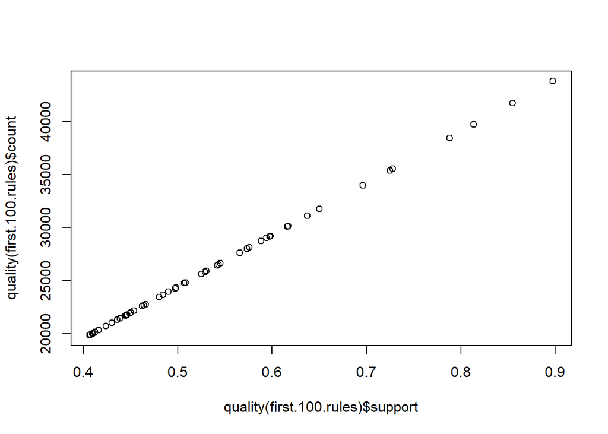

```r
first.100.rules <- head(sort(rules, by="support"),100)
plot(quality(first.100.rules)$support,quality(first.100.rules)$count)
```

```r
inspect(head(first.100.rules))
```

```
##     lhs                               rhs
## [1] {}                             => {native-country=United-States}
## [2] {}                             => {race=White}
## [3] {}                             => {fnlwgt=(1e+05,5e+05]}
## [4] {race=White}                   => {native-country=United-States}
## [5] {native-country=United-States} => {race=White}
## [6] {}                             => {hours-per-week=(30,50]}
##     support   confidence lift     count
## [1] 0.8974243 0.8974243  1.000000 43832
## [2] 0.8550428 0.8550428  1.000000 41762
## [3] 0.8136440 0.8136440  1.000000 39740
## [4] 0.7881127 0.9217231  1.027076 38493
## [5] 0.7881127 0.8781940  1.027076 38493
## [6] 0.7279800 0.7279800  1.000000 35556
```

En el grafico podemos ver una relación directa entre el soporte y la frecuencia. Eso es debido a que el soporte es el porcentaje de transacciones que contienen union(‘lhs’,‘rhs’)

## 9.3 Pregunta 3

1. Investigad el funcionamiento de la función **coverage()** y aplicadlo a la variable **rules**.
2. Lista las 10 reglas con **coverage** más alto.
3. Genera un gráfico de frecuencias por **coverage**.

```r
#Añadimos una columna coverage
rules.with.coverage <- rules
quality(rules.with.coverage) <- cbind(quality(rules.with.coverage), coverage = coverage(rules.with.coverage))

# Listamos las 10 reglas con mayor soporte
inspect(head(sort(rules.with.coverage, by="coverage"),10));
```

```
##      lhs                               rhs                              support confidence      lift count  coverage
## [1]  {}                             => {hours-per-week=(30,50]}       0.7279800  0.7279800 1.0000000 35556 1.0000000
## [2]  {}                             => {fnlwgt=(1e+05,5e+05]}         0.8136440  0.8136440 1.0000000 39740 1.0000000
## [3]  {}                             => {race=White}                   0.8550428  0.8550428 1.0000000 41762 1.0000000
## [4]  {}                             => {native-country=United-States} 0.8974243  0.8974243 1.0000000 43832 1.0000000
## [5]  {native-country=United-States} => {hours-per-week=(30,50]}       0.6502805  0.7246076 0.9953674 31761 0.8974243
## [6]  {native-country=United-States} => {fnlwgt=(1e+05,5e+05]}         0.7251136  0.8079942 0.9930561 35416 0.8974243
## [7]  {native-country=United-States} => {race=White}                   0.7881127  0.8781940 1.0270761 38493 0.8974243
## [8]  {race=White}                   => {hours-per-week=(30,50]}       0.6162524  0.7207270 0.9900368 30099 0.8550428
## [9]  {race=White}                   => {native-country=United-States} 0.7881127  0.9217231 1.0270761 38493 0.8550428
## [10] {race=White}                   => {fnlwgt=(1e+05,5e+05]}         0.6960403  0.8140415 1.0004885 33996 0.8550428
```

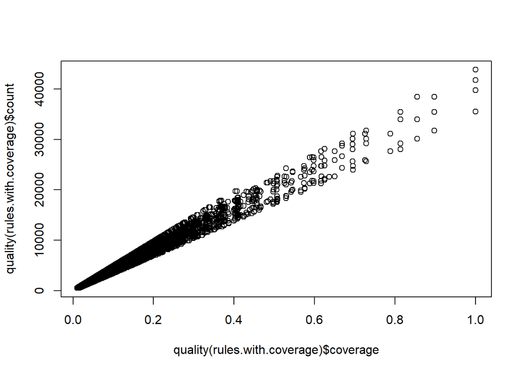

```r
plot(quality(rules.with.coverage)$coverage,quality(rules.with.coverage)$count)
```

Dado que la cobertura tambien es un calculo de soporte, deberia seguir una relación similar a la que hemos podido comprobar en la grafica del ejercicio anterior. Exactamente, esta grafica tiene una relación directa entre la cobertura y la frecuencia.

## 9.4 Pregunta 4

1. A partir del conjunto de reglas fsets generado con la función **eclat()** en el enunciado de la PEC, genera sets (conjuntos) de 2 items o caraterísticas.
2. A partir del set de 2 items generado, lista las 5 reglas con mayor soporte.

**Respuesta**

```r
two.Items = fsets[size(items(fsets)) == 2];
inspect(two.Items)
```

```
##       items                                  support count allConfidence
## [1]   {education=Masters,
##        education-num=(10,15]}             0.05439990  2657    0.17505600
## [2]   {occupation=Machine-op-inspct,
##        native-country=United-States}      0.05243438  2561    0.05842763
## [3]   {fnlwgt=(1e+05,5e+05],
##        occupation=Machine-op-inspct}      0.05286434  2582    0.06497232
## [4]   {occupation=Machine-op-inspct,
##        hours-per-week=(30,50]}            0.05495270  2684    0.07548656
## [5]   {workclass=Private,
##        occupation=Machine-op-inspct}      0.05900659  2882    0.08499971
## [6]   {workclass=Local-gov,
##        native-country=United-States}      0.06021457  2941    0.06709710
## [7]   {workclass=Local-gov,
##        race=White}                        0.05239343  2559    0.06127580
## [8]   {workclass=Local-gov,
##        fnlwgt=(1e+05,5e+05]}              0.05315098  2596    0.06532461
## [9]   {workclass=Local-gov,
##        hours-per-week=(30,50]}            0.05073502  2478    0.06969288
## [10]  {hours-per-week=(10,20],
##        native-country=United-States}      0.06256910  3056    0.06972075
## [11]  {race=White,
##        hours-per-week=(10,20]}            0.05804431  2835    0.06788468
## [12]  {fnlwgt=(1e+05,5e+05],
##        hours-per-week=(10,20]}            0.05493223  2683    0.06751384
## [13]  {education-num=(5,10],
##        hours-per-week=(10,20]}            0.05096024  2489    0.08155308
## [14]  {capital-gain=(0,1.5e+04],
##        native-country=United-States}      0.05861758  2863    0.06531758
## [15]  {race=White,
##        capital-gain=(0,1.5e+04]}          0.05626305  2748    0.06580145
## [16]  {fnlwgt=(1e+05,5e+05],
##        capital-gain=(0,1.5e+04]}          0.05198395  2539    0.06389029
## [17]  {hours-per-week=(20,30],
##        native-country=United-States}      0.06271242  3063    0.06988045
## [18]  {race=White,
##        hours-per-week=(20,30]}            0.05943655  2903    0.06951295
## [19]  {fnlwgt=(1e+05,5e+05],
##        hours-per-week=(20,30]}            0.05644732  2757    0.06937594
## [20]  {education-num=(5,10],
```

[output cut: 608 more lines]

```
##        fnlwgt=(1e+05,5e+05]}              0.57356374 28014    0.70493206
## [325] {workclass=Private,
##        hours-per-week=(30,50]}            0.52495803 25640    0.72111599
## [326] {hours-per-week=(30,50],
##        native-country=United-States}      0.65028050 31761    0.72460759
## [327] {race=White,
##        hours-per-week=(30,50]}            0.61625241 30099    0.72072698
## [328] {fnlwgt=(1e+05,5e+05],
##        hours-per-week=(30,50]}            0.59745711 29181    0.73429794
## [329] {fnlwgt=(1e+05,5e+05],
##        native-country=United-States}      0.72511363 35416    0.80799416
## [330] {fnlwgt=(1e+05,5e+05],
##        race=White}                        0.69604029 33996    0.81404147
## [331] {race=White,
##        native-country=United-States}      0.78811269 38493    0.87819401
```

```r
inspect(head(sort(two.Items, by="support"),10));
```

```
##      items                            support count allConfidence
## [1]  {race=White,
##       native-country=United-States} 0.7881127 38493     0.8781940
## [2]  {fnlwgt=(1e+05,5e+05],
##       native-country=United-States} 0.7251136 35416     0.8079942
## [3]  {fnlwgt=(1e+05,5e+05],
##       race=White}                   0.6960403 33996     0.8140415
## [4]  {hours-per-week=(30,50],
##       native-country=United-States} 0.6502805 31761     0.7246076
## [5]  {workclass=Private,
##       native-country=United-States} 0.6171942 30145     0.6877396
## [6]  {race=White,
##       hours-per-week=(30,50]}       0.6162524 30099     0.7207270
## [7]  {sex=Male,
##       native-country=United-States} 0.5983170 29223     0.6667047
## [8]  {fnlwgt=(1e+05,5e+05],
##       hours-per-week=(30,50]}       0.5974571 29181     0.7342979
## [9]  {workclass=Private,
##       race=White}                   0.5942427 29024     0.6949859
## [10] {race=White,
##       sex=Male}                     0.5883256 28735     0.6880657
```

## 9.5 Pregunta 5

Escoje una de las reglas generadas y comenta los valores de soporte, confianza y elevación que tiene asociados.  
1. ¿Qué significa cada uno de los 3 conceptos?  
2. Aplica cada una de las 3 definiciones a la regla seleccionada

**Respuesta** -**Soporte:** Es un indicador de tan frecuente es un itemset en el conjunto de datos. -**Confianza:** Es un indicador del grado de fiabilidad de una regla. -**Elevación:** Ratio del soporte observado contra el esperado si ‘lhs’ y ‘rhs’ fuesen independientes. Cuando elevación = 1 (independientes entre sí), no se puede establecer ninguna regla. Mayores valores de elevación indican asociaciones más fuertes.

## 9.6 Pregunta 6

El objetivo de todo estudio analítico es la extracción de conocimiento o inteligencia, **insight** en inglés.  
Explicad en este apartado qué conocimiento se puede extraer de nuestro juego de datos a partir de las reglas generadas.

**Respuesta** Muchas de las reglas, tenian un lift igual (o similar) a uno. Cuando esto pasa las variables son independientes y por tanto, no es posible extraer información de esa regla.

Lo que podemos hacer es calcular si una regla es significativa mediante el test de Fisher. La función **is.significant()** nos indica si una regla es significante comparando el p-value del test de Fisher con el alpha que nosotros decidamos (en este caso 0.05).

Haremos un analisis con las siguientes reglas: - Soporte de mas del 60% - Confianza de mas del 80% - Lift superior a 1 - Reglas que sean significantes

```r
metricas <- interestMeasure(rules, measure = c("support", "confidence","lift", "fishersExactTest"), transactions = Adult)
rules.significant <- is.significant(rules, Adult, method = "fisher", alpha = 0.05)
quality(rules) <- cbind(metricas, significant = rules.significant)
subrules.significant <- rules[quality(rules)$support > 0.6 & quality(rules)$confidence > 0.8 & quality(rules)$lift > 1.0 & quality(rules)$significant == TRUE];
inspect(head(sort(subrules.significant,by="confidence"), 10))
```

```
##     lhs                               rhs                              support confidence     lift fishersExactTest significant
## [1] {race=White}                   => {native-country=United-States} 0.7881127  0.9217231 1.027076     0.000000e+00        TRUE
## [2] {fnlwgt=(1e+05,5e+05],
##      race=White}                   => {native-country=United-States} 0.6370132  0.9151959 1.019803     2.355528e-81        TRUE
## [3] {fnlwgt=(1e+05,5e+05],
##      native-country=United-States} => {race=White}                   0.6370132  0.8785012 1.027435    1.714892e-119        TRUE
## [4] {native-country=United-States} => {race=White}                   0.7881127  0.8781940 1.027076     0.000000e+00        TRUE
```

Comentaremos estas reglas que nos han aparecido: - La gente de ‘raza’ blanca son nativos de Estados Unidos y viceversa( reglas 1 y 4). - Reglas similares nos aparecen (reglas 2 y 3). Podriamos descartar estas 2 debido a que las anteriores son mas genericas

Si modificamos el soporte y la confianza podemos encontrar otras reglas:

```r
subrules.significant <- rules[quality(rules)$support > 0.1 & quality(rules)$confidence > 0.95 & quality(rules)$lift > 1.0 & quality(rules)$significant == TRUE];
inspect(head(sort(subrules.significant,by="lift"), 5))
```

```
##     lhs                         rhs                       support confidence     lift fishersExactTest significant
## [1] {education=Bachelors}    => {education-num=(10,15]} 0.1643053          1 3.217947                0        TRUE
## [2] {education=Bachelors,
##      sex=Male}               => {education-num=(10,15]} 0.1135908          1 3.217947                0        TRUE
## [3] {workclass=Private,
##      education=Bachelors}    => {education-num=(10,15]} 0.1085746          1 3.217947                0        TRUE
## [4] {education=Bachelors,
##      hours-per-week=(30,50]} => {education-num=(10,15]} 0.1248106          1 3.217947                0        TRUE
## [5] {fnlwgt=(1e+05,5e+05],
##      education=Bachelors}    => {education-num=(10,15]} 0.1336964          1 3.217947                0        TRUE
```

En general, en estas reglas encontramos que la gente con educación universitaria (Bachelors) ha estudiado entre 10 y 15 años. Atención: cuanto mas bajo sea el soporte apareceran reglas que se den menos en nuestro set de datos, si bajamos demasiado este numero apareceran reglas que no se suelen dar en la vida real. El soporte minimo aceptable variara en función del tamaño de los datos de entrada.

Asi pues, modificanco las variables de soporte, confianza i lift podemos encontrar reglas que nos permitan extraer conocimiento de este set de datos. Incluso pueden ayudarnos a hacer predicciones futuras.